# Crysp-DM

**Projeto:** Análise de Vendas no E-commerce Brasileiro  
**Processo:** CRISP-DM  
**Autor:** Matheus Medina  
**Data:** 02.11.2025

## 📑 **Índice do Notebook — Etapas do CRISP-DM**

1. 🎯 Entendimento do Negócio
2. 📊 Entendimento dos Dados
3. 🧹 Preparação dos Dados
4. 🧠 Modelagem e Métricas
5. 📈 Avaliação e Conclusões

## Entendimento do Negócio

🎯 Entendimento do Negócio

> Nesta etapa descrevemos o contexto do projeto, objetivos estratégicos e métricas de sucesso.

O projeto tem como foco a análise de desempenho de um e-commerce brasileiro, com o objetivo de compreender o comportamento das vendas, dos clientes e da operação logística, utilizando como base os dados públicos da plataforma Olist. A partir dessa análise, busca-se identificar padrões de compra, tendências de faturamento, diferenças regionais e indicadores operacionais, como o tempo de entrega e o ticket médio por estado.

O entendimento do negócio envolve responder perguntas-chave, como:

Quais regiões (estados) concentram o maior faturamento e número de pedidos?

Quais formas de pagamento são mais utilizadas pelos clientes?

Qual é o comportamento do faturamento ao longo dos meses?

Como está o desempenho logístico em relação aos prazos de entrega?

Quais produtos e categorias apresentam maior volume de vendas?

Essas respostas auxiliam na tomada de decisão estratégica, permitindo otimizar campanhas de marketing, gestão de estoque, logística e relacionamento com o cliente. Ao final, o estudo fornece uma visão clara sobre como o e-commerce performa comercial e operacionalmente, sustentando futuras etapas de modelagem preditiva e planejamento de negócio.

## Entendimento dos Dados

📊 Entendimento dos Dados

> Nesta etapa, realizamos o levantamento, inspeção inicial e compreensão estrutural dos dados disponíveis para análise.

O conjunto de dados utilizado é composto por diversas tabelas que representam as principais entidades de um e-commerce brasileiro. Cada tabela contém informações específicas que, em conjunto, descrevem toda a jornada de compra — desde o pedido até a entrega ao cliente.

As tabelas analisadas incluem:

orders — informações gerais sobre os pedidos, incluindo status, datas de compra, aprovação e entrega.

order_items — detalhes dos itens de cada pedido, com preço, frete e identificadores de produto e vendedor.

payments — formas de pagamento utilizadas e valores correspondentes.

customers — cadastro de clientes, com localização (UF e CEP prefix).

products — catálogo de produtos, incluindo dimensões, peso e categoria.

sellers — informações dos vendedores, como código e localização.

Durante o entendimento dos dados, foram realizadas as seguintes ações:

- Visualização do tamanho e estrutura de cada tabela (quantidade de registros e colunas).
- Verificação de consistência entre chaves primárias e estrangeiras (como order_id, product_id e customer_id).
- Identificação de valores ausentes e inconsistentes, preparando o terreno para a etapa de limpeza e tratamento.
- Criação de uma base consolidada, para averiguação de tipo de dados preenchidos (object, datetime, int, float ou boolean)

Essa compreensão é fundamental para definir quais tabelas devem ser integradas e quais variáveis são mais relevantes para as análises de negócio.

```python
# 2. Entendimento dos Dados — Setup
import pandas as pd, numpy as np
import matplotlib.pyplot as plt
import seaborn as sns
import matplotlib.ticker as mtick
import matplotlib.dates as mdates
import calendar
from geobr import read_state
import geopandas as gpd
from pathlib import Path

pd.set_option('display.max_columns', None)
pd.set_option('display.width', 200)

DATA_DIR = Path('.')
# carregamentos Olist
customers      = pd.read_csv(DATA_DIR/'olist_customers_dataset.csv')
orders         = pd.read_csv(DATA_DIR/'olist_orders_dataset.csv')
order_items    = pd.read_csv(DATA_DIR/'olist_order_items_dataset.csv')
products       = pd.read_csv(DATA_DIR/'olist_products_dataset.csv')
sellers        = pd.read_csv(DATA_DIR/'olist_sellers_dataset.csv')
order_payments = pd.read_csv(DATA_DIR/'olist_order_payments_dataset.csv')
categories     = pd.read_csv(DATA_DIR/'product_category_name_translation.CSV')

# pequeno helper para formato
def fmt_mil(x):  return f'{int(x):,}'.replace(',', '.')
def fmt_moeda(x): return 'R$ ' + f'{x:,.2f}'.replace(',', '.')
```

```python
# SEÇÃO #2 — RESUMO DESCRITIVO AUTOMÁTICO (CRISP-DM)
# Gera uma visão rápida do dataset: tabelas, tamanhos,
# período de análise e faturamento aproximado.


from IPython.display import Markdown, display
import pandas as pd
import numpy as np

def _fmt_int_br(x: int) -> str:
    return f"{x:,}".replace(",", ".")

def _fmt_moeda_br(v: float) -> str:
    return ("R$ " + f"{v:,.2f}".replace(",", "X").replace(".", ",").replace("X", ".")) if pd.notna(v) else "—"

def resumo_dataset(tabelas: dict):
    """
    tabelas: dict com nome -> DataFrame, por ex.:
        {'orders': orders, 'order_items': order_items, 'payments': payments, ...}
    A função ignora entradas que não forem DataFrame.
    """
    # filtra só o que realmente é DataFrame
    tabs = {k: v for k, v in tabelas.items() if isinstance(v, pd.DataFrame)}

    texto = []
    texto.append("## 🧾 **Resumo Descritivo do Projeto**")
    texto.append(
        "Este notebook aplica o método **CRISP-DM** para explorar e analisar dados reais de um **e-commerce brasileiro**, "
        "com foco em **vendas, entregas, clientes e desempenho comercial**."
    )
    texto.append("")
    texto.append("**Conjunto de dados (visão por tabela):**")
    texto.append("")
    texto.append("| Tabela | Registros | Colunas | Exemplos de colunas |")
    texto.append("|:--|--:|--:|:--|")

    for nome, df in tabs.items():
        amostra_cols = ", ".join(list(df.columns[:6]))
        texto.append(f"| `{nome}` | {_fmt_int_br(len(df))} | {_fmt_int_br(len(df.columns))} | {amostra_cols} |")

    # --- métricas úteis se as tabelas existirem ---
    total_pedidos = None
    periodo_txt = None
    faturamento = None

    if 'orders' in tabs and 'order_id' in tabs['orders'].columns:
        total_pedidos = tabs['orders']['order_id'].nunique()

        # tenta achar coluna de data de compra
        col_data = None
        for c in ['order_purchase_timestamp', 'order_approved_at']:
            if c in tabs['orders'].columns:
                col_data = c
                break
        if col_data is not None:
            ds = pd.to_datetime(tabs['orders'][col_data], errors='coerce')
            if ds.notna().any():
                periodo_txt = f"{ds.min().date()} → {ds.max().date()}"

    if 'payments' in tabs and 'payment_value' in tabs['payments'].columns:
        faturamento = tabs['payments']['payment_value'].sum()

    texto.append("")
    texto.append("> ### 📌 **Resumo executivo**")
    if total_pedidos is not None:
        texto.append(f"- **Pedidos únicos**: {_fmt_int_br(total_pedidos)}")
    if periodo_txt is not None:
        texto.append(f"- **Período analisado**: {periodo_txt}")
    if faturamento is not None:
        texto.append(f"- **Faturamento bruto (soma de `payment_value`)**: {_fmt_moeda_br(faturamento)}")

    texto.append("")
    texto.append("> 🔍 Todas as tabelas relevantes serão integradas (quando necessário) em um DataFrame consolidado `df` para EDA, modelagem e visualizações.")

    display(Markdown("\n".join(texto)))
```

```python
resumo_dataset({
    'orders': orders,
    'order_items': order_items,
    'order_payments': order_payments,
    'customers': customers,
    'products': products,
    'sellers': sellers
})
```

🧾 **Resumo Descritivo do Projeto**

Este notebook aplica o método **CRISP-DM** para explorar e analisar dados reais de um **e-commerce brasileiro**, com foco em **vendas, entregas, clientes e desempenho comercial**.

**Conjunto de dados (visão por tabela):**

[output not shown]

- **Pedidos únicos**: 99.441

- **Período analisado**: 2016-09-04 → 2018-10-17

> 🔍 Todas as tabelas relevantes serão integradas (quando necessário) em um DataFrame consolidado `df` para EDA, modelagem e visualizações.

```python
# --- Verificação de consistência entre chaves primárias e estrangeiras ---

def verificar_relacionamentos(orders, order_items, payments, customers, products, sellers):
    print("🔍 Verificação de chaves primárias e estrangeiras:\n")

    # 1️⃣ Relação Orders ↔ Order Items
    inconsistentes_1 = order_items[~order_items['order_id'].isin(orders['order_id'])]
    print(f"Orders ↔ Order Items: {len(inconsistentes_1)} registros em order_items sem correspondência em orders")

    # 2️⃣ Relação Orders ↔ Payments
    inconsistentes_2 = payments[~payments['order_id'].isin(orders['order_id'])]
    print(f"Orders ↔ Payments: {len(inconsistentes_2)} registros em payments sem correspondência em orders")

    # 3️⃣ Relação Orders ↔ Customers
    inconsistentes_3 = orders[~orders['customer_id'].isin(customers['customer_id'])]
    print(f"Orders ↔ Customers: {len(inconsistentes_3)} registros em orders sem correspondência em customers")

    # 4️⃣ Relação Order Items ↔ Products
    inconsistentes_4 = order_items[~order_items['product_id'].isin(products['product_id'])]
    print(f"Order Items ↔ Products: {len(inconsistentes_4)} registros em order_items sem correspondência em products")

    # 5️⃣ Relação Order Items ↔ Sellers
    inconsistentes_5 = order_items[~order_items['seller_id'].isin(sellers['seller_id'])]
    print(f"Order Items ↔ Sellers: {len(inconsistentes_5)} registros em order_items sem correspondência em sellers")

    print("\n✅ Verificação concluída!")

# Executar a função
verificar_relacionamentos(orders, order_items, order_payments, customers, products, sellers)
```

```
🔍 Verificação de chaves primárias e estrangeiras:

Orders ↔ Order Items: 0 registros em order_items sem correspondência em orders
Orders ↔ Payments: 0 registros em payments sem correspondência em orders
Orders ↔ Customers: 0 registros em orders sem correspondência em customers
Order Items ↔ Products: 0 registros em order_items sem correspondência em products
Order Items ↔ Sellers: 0 registros em order_items sem correspondência em sellers

✅ Verificação concluída!
```

```python
# Juntando tabelas principais
df_final = (
    orders
    .merge(order_items, on='order_id', how='left')
    .merge(order_payments, on='order_id', how='left')
    .merge(customers, on='customer_id', how='left')
    .merge(products, on='product_id', how='left')
    .merge(sellers, on='seller_id', how='left')
)

print(f"Base consolidada criada com {df_final.shape[0]:,} linhas e {df_final.shape[1]} colunas.")
```

```
Base consolidada criada com 118,434 linhas e 33 colunas.
```

```python
df_final.info()
print("\nValores nulos restantes:\n", df_final.isnull().sum().sort_values(ascending=False).head(10))
```

```
<class 'pandas.core.frame.DataFrame'>
RangeIndex: 118434 entries, 0 to 118433
Data columns (total 33 columns):
 #   Column                         Non-Null Count   Dtype
---  ------                         --------------   -----
 0   order_id                       118434 non-null  object
 1   customer_id                    118434 non-null  object
 2   order_status                   118434 non-null  object
 3   order_purchase_timestamp       118434 non-null  object
 4   order_approved_at              118258 non-null  object
 5   order_delivered_carrier_date   116360 non-null  object
 6   order_delivered_customer_date  115037 non-null  object
 7   order_estimated_delivery_date  118434 non-null  object
 8   order_item_id                  117604 non-null  float64
 9   product_id                     117604 non-null  object
 10  seller_id                      117604 non-null  object
 11  shipping_limit_date            117604 non-null  object
 12  price                          117604 non-null  float64
 13  freight_value                  117604 non-null  float64
 14  payment_sequential             118431 non-null  float64
 15  payment_type                   118431 non-null  object
 16  payment_installments           118431 non-null  float64
 17  payment_value                  118431 non-null  float64
 18  customer_unique_id             118434 non-null  object
 19  customer_zip_code_prefix       118434 non-null  int64
 20  customer_city                  118434 non-null  object
 21  customer_state                 118434 non-null  object
 22  product_category_name          115906 non-null  object
 23  product_name_lenght            115906 non-null  float64
 24  product_description_lenght     115906 non-null  float64
 25  product_photos_qty             115906 non-null  float64
 26  product_weight_g               117584 non-null  float64
 27  product_length_cm              117584 non-null  float64
 28  product_height_cm              117584 non-null  float64
 29  product_width_cm               117584 non-null  float64
 30  seller_zip_code_prefix         117604 non-null  float64
 31  seller_city                    117604 non-null  object
 32  seller_state                   117604 non-null  object
dtypes: float64(14), int64(1), object(18)
memory usage: 29.8+ MB

Valores nulos restantes:
 order_delivered_customer_date    3397
product_photos_qty               2528
product_category_name            2528
product_description_lenght       2528
product_name_lenght              2528
order_delivered_carrier_date     2074
product_width_cm                  850
product_length_cm                 850
product_height_cm                 850
product_weight_g                  850
dtype: int64
```

```python
# Dicionário com os DataFrames principais
tabelas = {
    'customers': customers,
    'orders': orders,
    'order_items': order_items,
    'products': products,
    'sellers': sellers,
    'payments': order_payments
}

# Criação do resumo
resumo = []
for nome, df in tabelas.items():
    resumo.append({
        'Tabela': nome,
        'Linhas': f"{df.shape[0]:,}".replace(',', '.'),
        'Colunas': df.shape[1],
        'Valores Nulos': df.isnull().sum().sum(),
        'Valores Únicos (coluna chave)': df.iloc[:, 0].nunique(),
        'Tamanho (MB)': f"{df.memory_usage(deep=True).sum() / (1024**2):.2f}"
    })

resumo_df = pd.DataFrame(resumo)

# cores da tabela
resumo_df = resumo_df.style.set_caption("📊 Resumo das Tabelas do Dataset Olist")\
    .background_gradient(cmap="YlGnBu", subset=['Linhas', 'Valores Nulos'])\
    .set_table_styles([
        {'selector': 'caption', 'props': [('text-align', 'left'),
                                          ('font-size', '16px'),
                                          ('font-weight', 'bold'),
                                          ('color', '#004d4d'),
                                          ('padding', '10px 0')]},
        {'selector': 'th', 'props': [('background-color', '#008080'),
                                     ('color', 'white'),
                                     ('text-align', 'center')]},
        {'selector': 'td', 'props': [('text-align', 'center')]}
    ])

resumo_df
```

📊 Resumo das Tabelas do Dataset Olist

|  | Tabela | Linhas | Colunas | Valores Nulos | Valores Únicos (coluna chave) | Tamanho (MB) |
| --- | --- | --- | --- | --- | --- | --- |
| 0 | customers | 99.441 | 5 | 0 | 99441 | 26.59 |
| 1 | orders | 99.441 | 8 | 4908 | 99441 | 52.94 |
| 2 | order_items | 112.650 | 7 | 0 | 98666 | 35.99 |
| 3 | products | 32.951 | 9 | 2448 | 32951 | 6.30 |
| 4 | sellers | 3.095 | 4 | 0 | 3095 | 0.59 |
| 5 | payments | 103.886 | 5 | 0 | 99440 | 16.23 |

## Preparação dos Dados

🧹 Preparação dos Dados

> Nesta etapa, os dados brutos foram transformados e estruturados para garantir qualidade, consistência e adequação às análises subsequentes.

Após o entendimento das tabelas, iniciou-se o processo de limpeza e integração das bases. Essa etapa teve como objetivo garantir que os dados estejam consistentes, completos e prontos para exploração visual e estatística.

As principais ações realizadas foram:

- Tratamento de valores nulos:
- Colunas com ausência de dados foram preenchidas com valores adequados ao tipo da variável — por exemplo, “Não informado” para textos e média ou zero para valores numéricos.

Conversão de tipos de dados:

- Datas foram convertidas para o formato datetime, valores monetários ajustados para float e identificadores mantidos como string.

Criação do DataFrame consolidado (df):

- As tabelas foram integradas em uma estrutura única, combinando informações de pedidos, clientes, pagamentos e itens de venda — o que possibilitou as análises exploratórias e os gráficos de desempenho comercial. (utilizada a mesma base criada no entendimento dos dados)

Ao final, o dataset passou a representar de forma íntegra e confiável a operação do e-commerce, servindo como base sólida para as análises da próxima etapa.

```python
# --- TRATAMENTO DE VALORES NULOS NA TABELA PRODUCTS ---

# Textos e categorias → substituir por "Não informado"
products['product_category_name'] = products['product_category_name'].fillna("Não informado")
products['product_name_lenght'] = products['product_name_lenght'].fillna(0)
products['product_description_lenght'] = products['product_description_lenght'].fillna(0)
products['product_photos_qty'] = products['product_photos_qty'].fillna(0)

# Medidas físicas → preencher com média
for col in ['product_weight_g', 'product_length_cm', 'product_height_cm', 'product_width_cm']:
    media = products[col].mean()
    products[col] = products[col].fillna(media)

# Confirmação
print("Valores nulos após tratamento:")
print(products.isnull().sum()[products.isnull().sum() > 0])
```

```
Valores nulos após tratamento:
Series([], dtype: int64)
```

```python
# --- TRATAMENTO DE VALORES NULOS NA TABELA ORDERS ---

# 1) Garante tipo datetime
date_cols = [
    'order_purchase_timestamp',
    'order_approved_at',
    'order_delivered_carrier_date',
    'order_delivered_customer_date',
    'order_estimated_delivery_date'
]
for c in date_cols:
    orders[c] = pd.to_datetime(orders[c], errors='coerce')

# 2) Flags de imputação (antes de preencher)
orders['imputed_approved_at']          = orders['order_approved_at'].isna().astype('Int64')
orders['imputed_delivered_carrier']    = orders['order_delivered_carrier_date'].isna().astype('Int64')
orders['imputed_delivered_customer']   = orders['order_delivered_customer_date'].isna().astype('Int64')

# 3) Preenchimentos coerentes com o processo
# - Se não há aprovação, usa a data de compra
orders['order_approved_at'] = orders['order_approved_at'].fillna(orders['order_purchase_timestamp'])

# - Se não há data de entrega ao transportador, usa a aprovação; se ainda faltar, usa a compra
orders['order_delivered_carrier_date'] = orders['order_delivered_carrier_date']\
    .fillna(orders['order_approved_at'])\
    .fillna(orders['order_purchase_timestamp'])

# - Se não há data de entrega ao cliente, usa a estimada
orders['order_delivered_customer_date'] = orders['order_delivered_customer_date']\
    .fillna(orders['order_estimated_delivery_date'])

# 4) Correções mínimas de lógica temporal
# Se alguma data ficou antes da compra, forçamos a ser >= compra
orders.loc[orders['order_approved_at'] < orders['order_purchase_timestamp'], 'order_approved_at'] \
    = orders.loc[orders['order_approved_at'] < orders['order_purchase_timestamp'], 'order_purchase_timestamp']

orders.loc[orders['order_delivered_carrier_date'] < orders['order_approved_at'], 'order_delivered_carrier_date'] \
    = orders.loc[orders['order_delivered_carrier_date'] < orders['order_approved_at'], 'order_approved_at']

orders.loc[orders['order_delivered_customer_date'] < orders['order_delivered_carrier_date'], 'order_delivered_customer_date'] \
    = orders.loc[orders['order_delivered_customer_date'] < orders['order_delivered_carrier_date'], 'order_delivered_carrier_date']

# 5) Conferência: nulos restantes nas três colunas originalmente problemáticas
print("Nulos restantes (orders):")
print(orders[['order_approved_at','order_delivered_carrier_date','order_delivered_customer_date']].isna().sum())

# 6) Quantas imputações fizemos (para documentação)
print("\nImputações realizadas:")
print("order_approved_at           →", int(orders['imputed_approved_at'].sum()))
print("order_delivered_carrier_date→", int(orders['imputed_delivered_carrier'].sum()))
print("order_delivered_customer_date→", int(orders['imputed_delivered_customer'].sum()))
```

```
Nulos restantes (orders):
order_approved_at                0
order_delivered_carrier_date     0
order_delivered_customer_date    0
dtype: int64

Imputações realizadas:
order_approved_at           → 160
order_delivered_carrier_date→ 1783
order_delivered_customer_date→ 2965
```

```python
# --- 1) Datas -> datetime (df_final) ---
for col in ['order_purchase_timestamp', 'order_delivered_customer_date']:
    if col in df_final.columns:
        df_final[col] = pd.to_datetime(df_final[col], errors='coerce')

# --- 2) Valores monetários -> float (df_final) ---
for col in ['payment_value', 'price', 'freight_value']:
    if col in df_final.columns:
        df_final[col] = pd.to_numeric(df_final[col], errors='coerce')

# --- 3) Identificadores -> string (df_final) ---
for col in ['order_id', 'customer_id', 'product_id', 'seller_id']:
    if col in df_final.columns:
        df_final[col] = df_final[col].astype('string')

# --- 4) Colunas derivadas de data (df_final) ---
if 'order_purchase_timestamp' in df_final.columns:
    df_final['ano'] = df_final['order_purchase_timestamp'].dt.year
    df_final['mes'] = df_final['order_purchase_timestamp'].dt.month
    # Observação: requer locale pt_BR instalado no sistema
    df_final['dia_semana'] = df_final['order_purchase_timestamp'].dt.day_name(locale='pt_BR')

# =======================
# BLOCO DE KPIs (orders)
# =======================

# 5) Datas -> datetime (orders)
for c in ["order_purchase_timestamp","order_approved_at",
          "order_delivered_carrier_date","order_delivered_customer_date",
          "order_estimated_delivery_date"]:
    if c in orders.columns:
        orders[c] = pd.to_datetime(orders[c], errors="coerce")

# 6) Identificadores -> string (orders)
for col in ['order_id', 'customer_id']:
    if col in orders.columns:
        orders[col] = orders[col].astype('string')

# 7) Cálculo de KPIs
kpi_total = len(orders)
kpi_entregues = (orders["order_status"] == "delivered").sum()
kpi_pct_entregues = 100 * kpi_entregues / kpi_total if kpi_total > 0 else 0

tempo_entrega = (orders["order_delivered_customer_date"] - orders["order_purchase_timestamp"]).dt.days
kpi_tempo_medio = float(np.nanmean(tempo_entrega)) if len(tempo_entrega) else float('nan')

print(f"📦 Pedidos: {kpi_total:,}".replace(",","."))
print(f"✅ Entregues: {kpi_entregues:,} ({kpi_pct_entregues:.1f}%)".replace(",","."))
print(f"⏱️ Tempo médio de entrega: {kpi_tempo_medio:.1f} dias")
```

```
📦 Pedidos: 99.441
✅ Entregues: 96.478 (97.0%)
⏱️ Tempo médio de entrega: 12.5 dias
```

```python
# --- RESUMO DA BASE CONSOLIDADA ---

# 1️⃣ Mostrar tamanho e estrutura geral
linhas, colunas = df_final.shape
memoria_mb = df_final.memory_usage(deep=True).sum() / (1024**2)

print(f"📦 Base consolidada criada com {linhas:,} linhas e {colunas} colunas.".replace(",", "."))
print(f"💾 Tamanho em memória: {memoria_mb:.2f} MB\n")

# 2️⃣ Mostrar as 5 primeiras linhas
display(df_final.head().style.set_caption("📊 Primeiras 5 linhas da Base Consolidada (df_final)")
        .set_table_styles([
            {'selector': 'caption', 'props': [('text-align', 'left'),
                                              ('font-size', '16px'),
                                              ('font-weight', 'bold'),
                                              ('color', '#004d4d'),
                                              ('padding', '10px 0')]},
            {'selector': 'th', 'props': [('background-color', '#008080'),
                                         ('color', 'white'),
                                         ('text-align', 'center')]},
            {'selector': 'td', 'props': [('text-align', 'center')]}
        ])
)
```

```
📦 Base consolidada criada com 118.434 linhas e 36 colunas.
💾 Tamanho em memória: 145.00 MB
```

📊 Primeiras 5 linhas da Base Consolidada (df_final)

|  | order_id | customer_id | order_status | order_purchase_timestamp | order_approved_at | order_delivered_carrier_date | order_delivered_customer_date | order_estimated_delivery_date | order_item_id | product_id | seller_id | shipping_limit_date | price | freight_value | payment_sequential | payment_type | payment_installments | payment_value | customer_unique_id | customer_zip_code_prefix | customer_city | customer_state | product_category_name | product_name_lenght | product_description_lenght | product_photos_qty | product_weight_g | product_length_cm | product_height_cm | … |
| --- | --- | --- | --- | --- | --- | --- | --- | --- | --- | --- | --- | --- | --- | --- | --- | --- | --- | --- | --- | --- | --- | --- | --- | --- | --- | --- | --- | --- | --- | --- |
| 0 | e481f51cbdc54678b7cc49136f2d6af7 | 9ef432eb6251297304e76186b10a928d | delivered | 2017-10-02 10:56:33 | 2017-10-02 11:07:15 | 2017-10-04 19:55:00 | 2017-10-10 21:25:13 | 2017-10-18 00:00:00 | 1.000000 | 87285b34884572647811a353c7ac498a | 3504c0cb71d7fa48d967e0e4c94d59d9 | 2017-10-06 11:07:15 | 29.990000 | 8.720000 | 1.000000 | credit_card | 1.000000 | 18.120000 | 7c396fd4830fd04220f754e42b4e5bff | 3149 | sao paulo | SP | utilidades_domesticas | 40.000000 | 268.000000 | 4.000000 | 500.000000 | 19.000000 | 8.000000 | … |
| 1 | e481f51cbdc54678b7cc49136f2d6af7 | 9ef432eb6251297304e76186b10a928d | delivered | 2017-10-02 10:56:33 | 2017-10-02 11:07:15 | 2017-10-04 19:55:00 | 2017-10-10 21:25:13 | 2017-10-18 00:00:00 | 1.000000 | 87285b34884572647811a353c7ac498a | 3504c0cb71d7fa48d967e0e4c94d59d9 | 2017-10-06 11:07:15 | 29.990000 | 8.720000 | 3.000000 | voucher | 1.000000 | 2.000000 | 7c396fd4830fd04220f754e42b4e5bff | 3149 | sao paulo | SP | utilidades_domesticas | 40.000000 | 268.000000 | 4.000000 | 500.000000 | 19.000000 | 8.000000 | … |
| 2 | e481f51cbdc54678b7cc49136f2d6af7 | 9ef432eb6251297304e76186b10a928d | delivered | 2017-10-02 10:56:33 | 2017-10-02 11:07:15 | 2017-10-04 19:55:00 | 2017-10-10 21:25:13 | 2017-10-18 00:00:00 | 1.000000 | 87285b34884572647811a353c7ac498a | 3504c0cb71d7fa48d967e0e4c94d59d9 | 2017-10-06 11:07:15 | 29.990000 | 8.720000 | 2.000000 | voucher | 1.000000 | 18.590000 | 7c396fd4830fd04220f754e42b4e5bff | 3149 | sao paulo | SP | utilidades_domesticas | 40.000000 | 268.000000 | 4.000000 | 500.000000 | 19.000000 | 8.000000 | … |
| 3 | 53cdb2fc8bc7dce0b6741e2150273451 | b0830fb4747a6c6d20dea0b8c802d7ef | delivered | 2018-07-24 20:41:37 | 2018-07-26 03:24:27 | 2018-07-26 14:31:00 | 2018-08-07 15:27:45 | 2018-08-13 00:00:00 | 1.000000 | 595fac2a385ac33a80bd5114aec74eb8 | 289cdb325fb7e7f891c38608bf9e0962 | 2018-07-30 03:24:27 | 118.700000 | 22.760000 | 1.000000 | boleto | 1.000000 | 141.460000 | af07308b275d755c9edb36a90c618231 | 47813 | barreiras | BA | perfumaria | 29.000000 | 178.000000 | 1.000000 | 400.000000 | 19.000000 | 13.000000 | … |
| 4 | 47770eb9100c2d0c44946d9cf07ec65d | 41ce2a54c0b03bf3443c3d931a367089 | delivered | 2018-08-08 08:38:49 | 2018-08-08 08:55:23 | 2018-08-08 13:50:00 | 2018-08-17 18:06:29 | 2018-09-04 00:00:00 | 1.000000 | aa4383b373c6aca5d8797843e5594415 | 4869f7a5dfa277a7dca6462dcf3b52b2 | 2018-08-13 08:55:23 | 159.900000 | 19.220000 | 1.000000 | credit_card | 3.000000 | 179.120000 | 3a653a41f6f9fc3d2a113cf8398680e8 | 75265 | vianopolis | GO | automotivo | 46.000000 | 232.000000 | 1.000000 | 420.000000 | 24.000000 | 19.000000 | … |

## Modelagem e Métricas

📈 Modelagem e Métricas

> Nesta etapa, foram realizadas investigações iniciais para compreender o comportamento dos principais indicadores do e-commerce, transformando os dados tratados em informações estratégicas.

Após o entendimento e preparação dos dados, esta etapa tem como objetivo aplicar técnicas quantitativas para medir o desempenho do e-commerce e identificar padrões que possam embasar decisões estratégicas.

Foram definidas métricas descritivas e de desempenho, como volume de pedidos, faturamento, ticket médio, tempo de entrega e percentis de distribuição, permitindo avaliar o comportamento operacional e comercial da plataforma.

Embora este projeto não envolva um modelo preditivo supervisionado, a etapa de modelagem aqui é entendida como o processo de construção e análise de indicadores — traduzindo dados em métricas que ajudam a responder às perguntas de negócio e a mensurar o sucesso das operações.

Essas métricas servem como base para monitorar resultados, propor melhorias e apoiar decisões táticas voltadas à eficiência logística, precificação e experiência do cliente.

A etapa buscou identificar padrões, tendências e possíveis anomalias nos pedidos, pagamentos, prazos de entrega e características dos clientes.

Foram aplicadas técnicas de visualização com o objetivo de responder às seguintes questões de negócio:

- Como evoluiu o volume de vendas ao longo do tempo?
- Quais estados concentram o maior faturamento?
- Como se distribuem os valores de ticket médio e frete?
- Quais são os tempos médios e percentis de entrega dos pedidos?

Os resultados apresentados nesta seção permitem uma visão ampla do desempenho comercial da plataforma, fornecendo subsídios para decisões estratégicas relacionadas a logística, precificação e experiência do cliente.

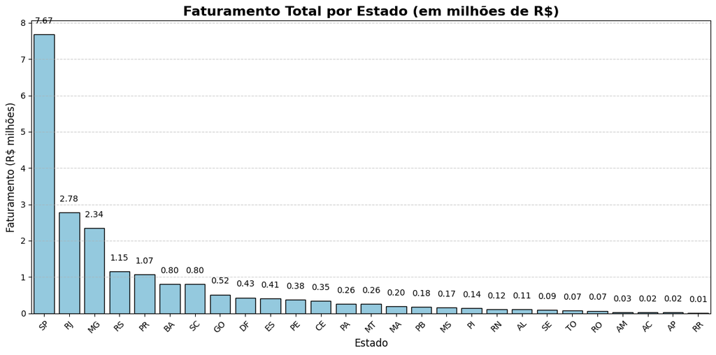

```python
# Ordenar os estados pelo faturamento (maior → menor)
vendas_estado = df_final.groupby('customer_state')['payment_value'].sum()
vendas_estado_sorted = vendas_estado.sort_values(ascending=False)

plt.figure(figsize=(12,6))
ax = sns.barplot(
    x=vendas_estado_sorted.index,
    y=vendas_estado_sorted.values / 1_000_000,
    color='skyblue',
    edgecolor='black'
)

# Títulos e legendas
plt.title('Faturamento Total por Estado (em milhões de R$)', fontsize=16, fontweight='bold')
plt.xlabel('Estado', fontsize=12)
plt.ylabel('Faturamento (R$ milhões)', fontsize=12)

# Rótulos acima das barras
for i, v in enumerate(vendas_estado_sorted.values / 1_000_000):
    ax.text(i, v + 0.3, f'{v:.2f}', ha='center', fontsize=10, color='black')

# Ajustes visuais
plt.xticks(rotation=45)
plt.grid(axis='y', linestyle='--', alpha=0.6)
plt.tight_layout()
plt.show()
```

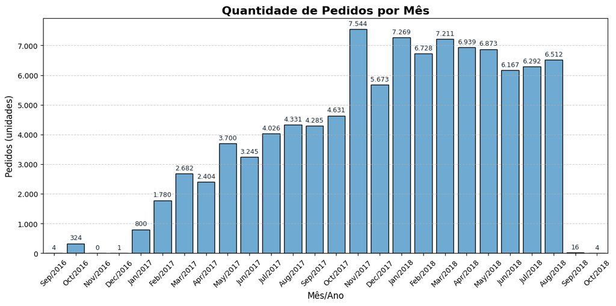

```python
# Garante datetime
orders['order_purchase_timestamp'] = pd.to_datetime(orders['order_purchase_timestamp'], errors='coerce')

# Agrupa pedidos por mês (conta order_id únicos)
pedidos_mes = (
    orders
    .set_index('order_purchase_timestamp')
    .resample('M')['order_id']
    .nunique()
)

# Cria rótulos "Mês/Ano" (Ex: Jan/2018)
meses_labels = [f"{calendar.month_abbr[d.month].capitalize()}/{d.year}" for d in pedidos_mes.index]

# Gráfico
plt.figure(figsize=(12,6))
ax = sns.barplot(x=meses_labels, y=pedidos_mes.values, color="#5DADE2", edgecolor="black")

# Títulos e eixos
plt.title("Quantidade de Pedidos por Mês", fontsize=16, fontweight='bold')
plt.xlabel("Mês/Ano", fontsize=12)
plt.ylabel("Pedidos (unidades)", fontsize=12)
plt.grid(axis="y", linestyle="--", alpha=0.6)
plt.xticks(rotation=45)

# Formata y com separador de milhar
ax.yaxis.set_major_formatter(mtick.FuncFormatter(lambda x, _: f"{int(x):,}".replace(",", ".")))

# Anota os valores acima das barras
for i, v in enumerate(pedidos_mes.values):
    ax.text(i, v + max(pedidos_mes.values)*0.01, f"{int(v):,}".replace(",", "."),
            ha="center", va="bottom", fontsize=9, color="#1B2631")

plt.tight_layout()
plt.show()
```

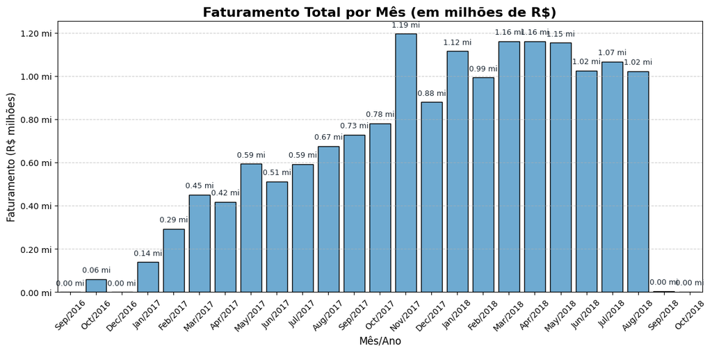

```python
# 1) Garantir colunas necessárias
if 'order_purchase_timestamp' not in df.columns:
    df = df.merge(
        orders[['order_id', 'order_purchase_timestamp']],
        on='order_id', how='left'
    )

# 2) Tipos e filtro de valores válidos
df['order_purchase_timestamp'] = pd.to_datetime(df['order_purchase_timestamp'], errors='coerce')
df['payment_value'] = pd.to_numeric(df['payment_value'], errors='coerce')
base = df.dropna(subset=['order_purchase_timestamp'])
base = base[base['payment_value'] > 0]

# 3) Agregar faturamento por mês (R$ milhões)
vendas_mes = (
    base
    .groupby(base['order_purchase_timestamp'].dt.to_period('M'))['payment_value']
    .sum()
)
vendas_mes.index = vendas_mes.index.to_timestamp()

# 4) Rótulos Mês/Ano
labels = [f"{calendar.month_abbr[d.month].capitalize()}/{d.year}" for d in vendas_mes.index]

# 5) Plot
plt.figure(figsize=(12,6))
ax = sns.barplot(
    x=labels,
    y=vendas_mes.values / 1_000_000,  # milhões de R$
    color="#5DADE2",
    edgecolor="black"
)

# 6) Estética
plt.title("Faturamento Total por Mês (em milhões de R$)", fontsize=16, fontweight='bold')
plt.xlabel("Mês/Ano", fontsize=12)
plt.ylabel("Faturamento (R$ milhões)", fontsize=12)
plt.grid(axis="y", linestyle="--", alpha=0.6)
plt.xticks(rotation=45)

# 7) Formatação do eixo Y e casas decimais
ax.yaxis.set_major_formatter(mtick.FuncFormatter(lambda x, _: f"{x:,.2f}".replace(',', '.') + ' mi'))

# 8) Anotar valores nas barras
y_vals = vendas_mes.values / 1_000_000
offset = 0.02 * (y_vals.max() if len(y_vals) else 1)
for i, v in enumerate(y_vals):
    ax.text(
        i, v + offset,
        f"{v:,.2f}".replace(',', '.') + ' mi',
        ha="center", va="bottom", fontsize=9, color="#1B2631"
    )

plt.tight_layout()
plt.show()
```

```python
# Considera apenas pedidos com pagamento > 0
df_pago = df[df['payment_value'] > 0].copy()

# Ticket por pedido (soma por order_id)
ticket = df_pago.groupby('order_id')['payment_value'].sum()

# P95 para “cortar” a cauda no gráfico principal
p95 = ticket.quantile(0.95)

# Série “miolo” limitada ao P95 (para visual legível)
ticket_clip = ticket.clip(upper=p95)

# Bins “amigáveis” para o histograma principal
bin_width = 50  # ajuste se quiser 25/100
bins_main = np.arange(0, ticket_clip.max() + bin_width, bin_width)
```

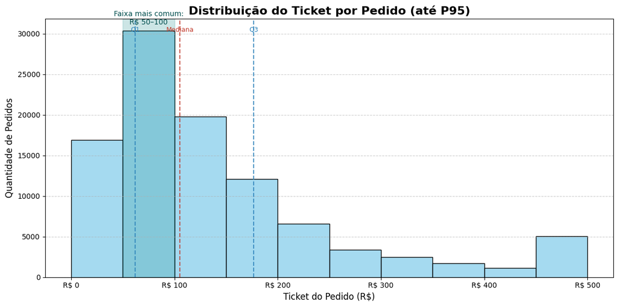

```
Mais pedidos na faixa de 50 a 100 reais
```

```python
ticket_pago = df[df['payment_value'] > 0].groupby('order_id')['payment_value'].sum()


# (opcional) focar no miolo e reduzir cauda: manter até o p95
p95 = ticket.quantile(0.95)
ticket_clip = ticket.clip(upper=p95)

# bins com largura “amigável”
bin_width = 50   # R$ por classe; ajuste para 20/25/100 se preferir
bins = np.arange(0, ticket_clip.max()+bin_width, bin_width)

plt.figure(figsize=(12,6))
ax = sns.histplot(ticket_clip, bins=bins, kde=False, color='skyblue', edgecolor='black')

# estética
plt.title('Distribuição do Ticket por Pedido (até P95)', fontsize=16, fontweight='bold')
plt.xlabel('Ticket do Pedido (R$)', fontsize=12)
plt.ylabel('Quantidade de Pedidos', fontsize=12)
plt.grid(axis='y', linestyle='--', alpha=0.6)
ax.xaxis.set_major_formatter(mtick.FuncFormatter(lambda x, _: f'R$ {x:,.0f}'.replace(',', '.')))
plt.tight_layout()

# destaca o bin mais frequente (a “moda” binned)
counts, edges = np.histogram(ticket_clip, bins=bins)
imax = counts.argmax()
moda_ini, moda_fim = edges[imax], edges[imax+1]
plt.axvspan(moda_ini, moda_fim, color='#008080', alpha=0.2)
plt.text((moda_ini+moda_fim)/2, counts[imax]*1.02,
         f'Faixa mais comum:\nR$ {moda_ini:,.0f}–{moda_fim:,.0f}'.replace(',', '.'),
         ha='center', va='bottom', fontsize=10, color='#004d4d')

# median e Q1/Q3
q1, med, q3 = ticket.median()*0+ticket.quantile(0.25), ticket.median(), ticket.quantile(0.75)
for q, lbl, col in [(q1,'Q1', '#2980B9'), (med,'Mediana', '#C0392B'), (q3,'Q3', '#2980B9')]:
    plt.axvline(q, color=col, linestyle='--', alpha=0.8)
    plt.text(q, ax.get_ylim()[1]*0.95, lbl, ha='center', color=col, fontsize=9)

plt.show()

print(f"Mais pedidos na faixa de 50 a 100 reais")
```

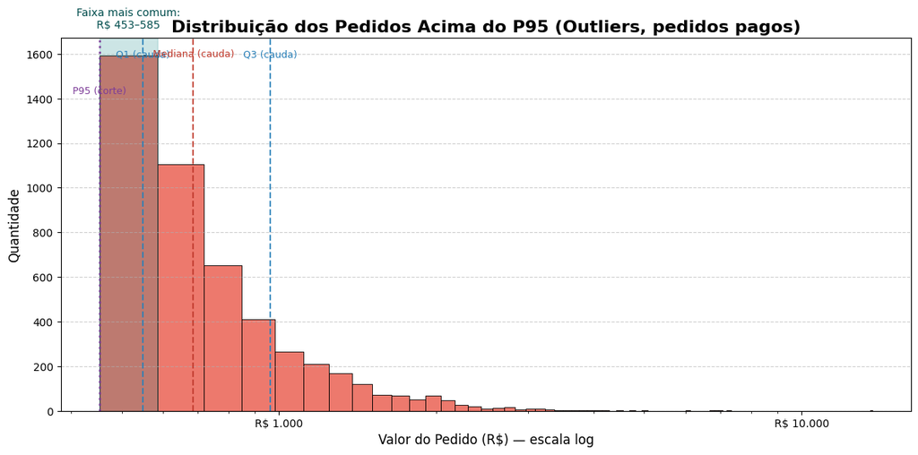

```
Quartis do conjunto total (referência): Q1=62. Mediana=105. Q3=177
```

```python
# --- dados de base já existentes:
# ticket = df[df['payment_value'] > 0].groupby('order_id')['payment_value'].sum()
# p95 = ticket.quantile(0.95)

outliers = ticket[ticket > p95].copy()
if outliers.empty:
    print("Não há pedidos acima do P95.")
else:
    plt.figure(figsize=(12,6))
    ax2 = sns.histplot(outliers, bins=100, color='#E74C3C', edgecolor='black')  # mais bins para detalhar a cauda

    plt.title('Distribuição dos Pedidos Acima do P95 (Outliers, pedidos pagos)', fontsize=16, fontweight='bold')
    plt.xlabel('Valor do Pedido (R$) — escala log', fontsize=12)
    plt.ylabel('Quantidade', fontsize=12)
    plt.grid(axis='y', linestyle='--', alpha=0.6)

    # Escala logarítmica no eixo X
    plt.xscale('log')

    # Formatter bonito com R$
    def fmt_val(x, _):
        try:
            return 'R$ ' + format(int(x), ',').replace(',', '.')
        except Exception:
            return ''
    ax2.xaxis.set_major_formatter(mtick.FuncFormatter(fmt_val))

    # ===== Moda (faixa mais frequente) da cauda =====
    counts, edges = np.histogram(outliers.values, bins=100)
    imax = counts.argmax()
    moda_ini, moda_fim = edges[imax], edges[imax+1]
    plt.axvspan(moda_ini, moda_fim, color='#008080', alpha=0.2)
    ymax = ax2.get_ylim()[1]
    plt.text(np.sqrt(moda_ini*moda_fim), ymax*1.02,  # posição ~centro geométrico (bom para escala log)
             f'Faixa mais comum:\nR$ {moda_ini:,.0f}–{moda_fim:,.0f}'.replace(',', '.'),
             ha='center', va='bottom', fontsize=10, color='#004d4d')

    # ===== Quartis/Mediana da cauda (>P95) =====
    q1_tail, med_tail, q3_tail = outliers.quantile([0.25, 0.5, 0.75])
    for xq, lbl, col in [
        (q1_tail, 'Q1 (cauda)', '#2980B9'),
        (med_tail,'Mediana (cauda)', '#C0392B'),
        (q3_tail, 'Q3 (cauda)', '#2980B9')
    ]:
        plt.axvline(xq, color=col, linestyle='--', alpha=0.85)
        plt.text(xq, ymax*0.95, lbl, ha='center', color=col, fontsize=9, rotation=0)

    # ===== Linha do P95 (referência do corte) =====
    plt.axvline(p95, color='#7D3C98', linestyle=':', linewidth=2, alpha=0.9)
    plt.text(p95, ymax*0.85, 'P95 (corte)', ha='center', color='#7D3C98', fontsize=9)

    plt.tight_layout()
    plt.show()

    # (Opcional) mostrar também Q1/Mediana/Q3 do conjunto inteiro, se caírem no range
    q1_full, med_full, q3_full = ticket.quantile([0.25, 0.5, 0.75])
    # Eles normalmente ficam < P95; se quiser, pode imprimir abaixo como observação:
    print(f"Quartis do conjunto total (referência): "
          f"Q1={q1_full:,.0f}, Mediana={med_full:,.0f}, Q3={q3_full:,.0f}".replace(',', '.'))
```

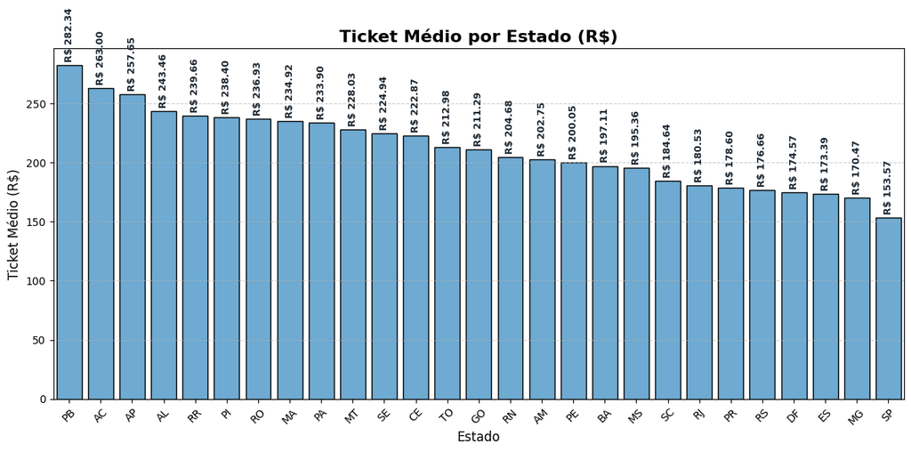

```python
# --- TICKET MÉDIO POR ESTADO (RÓTULOS ALINHADOS E DIAGONAIS) ---

ticket_estado = df_final.groupby('customer_state')['payment_value'].mean().sort_values(ascending=False)

plt.figure(figsize=(12,6))
ax = sns.barplot(
    x=ticket_estado.index,
    y=ticket_estado.values,
    color='#5DADE2',
    edgecolor='black'
)

plt.title('Ticket Médio por Estado (R$)', fontsize=16, fontweight='bold')
plt.xlabel('Estado', fontsize=12)
plt.ylabel('Ticket Médio (R$)', fontsize=12)
plt.grid(axis='y', linestyle='--', alpha=0.6)
plt.xticks(rotation=45)

# 🔹 Rótulos centralizados e inclinados
for p in ax.patches:
    ax.text(
        p.get_x() + p.get_width() / 2,      # centro da barra
        p.get_height() + (ticket_estado.max() * 0.01),  # ligeiramente acima
        f"R$ {p.get_height():,.2f}".replace(',', '.'),  # formatação
        ha='center', va='bottom',
        rotation=90, fontsize=9,
        color='#1B2631', fontweight='bold'
    )

plt.tight_layout()
plt.show()
```

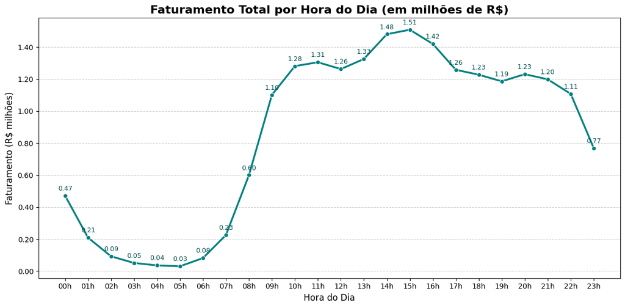

```python
# Extrai hora da compra
df_final['hora_compra'] = df_final['order_purchase_timestamp'].dt.hour

# Agrupa faturamento por hora
vendas_hora = df_final.groupby('hora_compra')['payment_value'].sum()

# Converte para milhões (ajuste se preferir milhar)
vendas_hora_milhoes = vendas_hora / 1_000_000

plt.figure(figsize=(12,6))
sns.lineplot(x=vendas_hora_milhoes.index, y=vendas_hora_milhoes.values,
             color="#008080", marker="o", linewidth=2.5)

# Estética geral
plt.title("Faturamento Total por Hora do Dia (em milhões de R$)", fontsize=16, fontweight='bold')
plt.xlabel("Hora do Dia", fontsize=12)
plt.ylabel("Faturamento (R$ milhões)", fontsize=12)
plt.grid(axis="y", linestyle="--", alpha=0.6)
plt.xticks(range(0, 24), [f"{h:02d}h" for h in range(0, 24)])
plt.tight_layout()

# Formata o eixo Y com separador de milhar e 1 casa decimal
plt.gca().yaxis.set_major_formatter(mtick.FuncFormatter(lambda x, _: f"{x:,.2f}".replace(",", ".")))

# Adiciona rótulos nos pontos
for x, y in zip(vendas_hora_milhoes.index, vendas_hora_milhoes.values):
    plt.text(x, y + max(vendas_hora_milhoes.values)*0.015, f"{y:,.2f}".replace(",", "."),
             ha="center", va="bottom", fontsize=9, color="#004d4d")

plt.show()
```

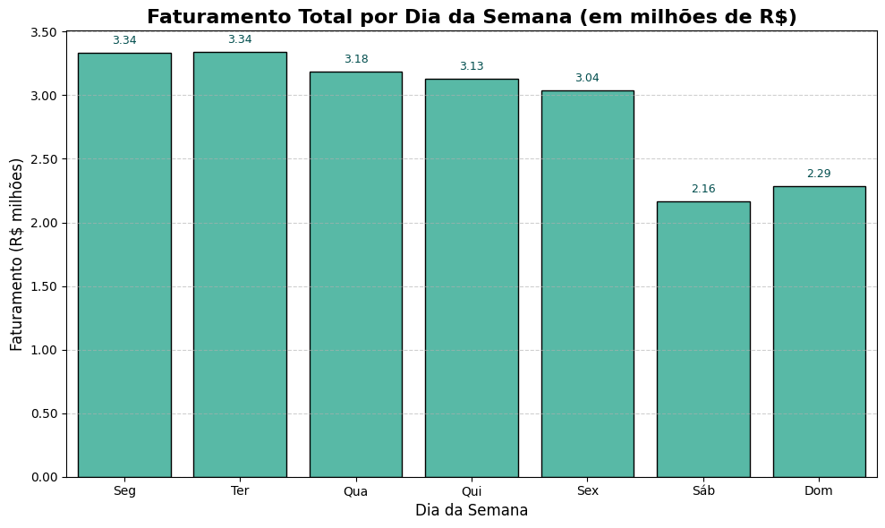

```python
# 1) Garantias e preparo
df_final['order_purchase_timestamp'] = pd.to_datetime(df_final['order_purchase_timestamp'], errors='coerce')
df_pago = df_final[df_final['payment_value'] > 0].copy()

# 2) Dia da semana via número (evita problemas de locale)
df_pago['weekday_num'] = df_pago['order_purchase_timestamp'].dt.dayofweek  # 0=seg, 6=dom
map_labels = {0:'Seg', 1:'Ter', 2:'Qua', 3:'Qui', 4:'Sex', 5:'Sáb', 6:'Dom'}

# 3) Agregação e ordenação correta (Seg→Dom)
vendas_semana = (df_pago
                 .groupby('weekday_num')['payment_value']
                 .sum()
                 .reindex(range(7)))  # garante ordem 0..6

vendas_semana_m = vendas_semana / 1_000_000
labels = [map_labels[i] for i in vendas_semana_m.index]

# 4) Plot bonito
plt.figure(figsize=(10,6))
ax = sns.barplot(x=labels, y=vendas_semana_m.values, color='#48C9B0', edgecolor='black')

plt.title('Faturamento Total por Dia da Semana (em milhões de R$)', fontsize=16, fontweight='bold')
plt.xlabel('Dia da Semana', fontsize=12)
plt.ylabel('Faturamento (R$ milhões)', fontsize=12)
plt.grid(axis='y', linestyle='--', alpha=0.6)

# Formatação do eixo Y e anotações
ax.yaxis.set_major_formatter(mtick.FuncFormatter(lambda x, _: f'{x:,.2f}'.replace(',', '.')))
for i, v in enumerate(vendas_semana_m.values):
    ax.text(i, v + max(vendas_semana_m.values)*0.015,
            f'{v:,.2f}'.replace(',', '.'),
            ha='center', va='bottom', fontsize=9, color="#004d4d")

plt.tight_layout()
plt.show()
```

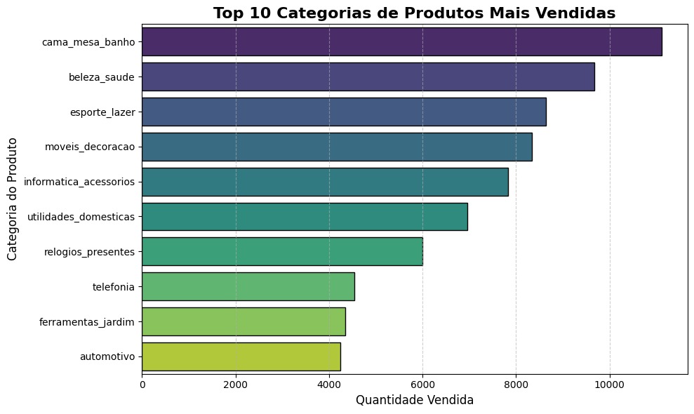

```python
# Junta com a tabela de produtos para trazer a categoria
top_produtos = (
    order_items
    .merge(products[['product_id', 'product_category_name']], on='product_id', how='left')
    .groupby('product_category_name')['product_id']
    .count()
    .sort_values(ascending=False)
    .head(10)
)

plt.figure(figsize=(10,6))
sns.barplot(y=top_produtos.index, x=top_produtos.values, palette='viridis', edgecolor='black')
plt.title('Top 10 Categorias de Produtos Mais Vendidas', fontsize=16, fontweight='bold')
plt.xlabel('Quantidade Vendida', fontsize=12)
plt.ylabel('Categoria do Produto', fontsize=12)
plt.grid(axis='x', linestyle='--', alpha=0.6)
plt.tight_layout()
plt.show()
```

```python
# Agrupa os dados
tabela_pagamentos = (
    df.groupby('payment_type')
      .agg(
          Pedidos=('order_id', 'nunique'),
          Faturamento=('payment_value', 'sum')
      )
      .reset_index()
)

# Formata os valores
tabela_pagamentos['Faturamento'] = tabela_pagamentos['Faturamento'].apply(lambda x: f"R$ {x:,.2f}".replace(",", "."))
tabela_pagamentos['Pedidos'] = tabela_pagamentos['Pedidos'].apply(lambda x: f"{x:,}".replace(",", "."))

# Capitaliza os meios de pagamento
tabela_pagamentos['payment_type'] = tabela_pagamentos['payment_type'].str.replace("_", " ").str.capitalize()

# Adiciona linha de total
total_pedidos = df['order_id'].nunique()
total_faturamento = df['payment_value'].sum()
linha_total = pd.DataFrame({
    'payment_type': ['Total Geral'],
    'Pedidos': [f"{total_pedidos:,}".replace(",", ".")],
    'Faturamento': [f"R$ {total_faturamento:,.2f}".replace(",", ".")]
})
tabela_pagamentos = pd.concat([tabela_pagamentos, linha_total], ignore_index=True)

# Exibe tabela estilizada
tabela_estilo = (
    tabela_pagamentos.style
    .set_caption("Distribuição dos Meios de Pagamento (Pedidos e Faturamento)")
    .set_table_styles([
        {"selector": "caption", "props": [("text-align", "center"), ("font-size", "14px"), ("font-weight", "bold"), ("color", "#d4efdf")]},
        {"selector": "th", "props": [("background-color", "#004d4d"), ("color", "white"), ("text-align", "center"), ("font-weight", "bold")]},
        {"selector": "td", "props": [("text-align", "center"), ("font-size", "12px"), ("padding", "6px")]},
        {"selector": "tr:nth-child(even)", "props": [("background-color", "#0C0C0C")]},
        {"selector": "tr:hover", "props": [("background-color", "#d4efdf")]}
    ])
)

tabela_estilo
```

Distribuição dos Meios de Pagamento (Pedidos e Faturamento)

|  | payment_type | Pedidos | Faturamento |
| --- | --- | --- | --- |
| 0 | Boleto | 19.784 | R$ 2.869.361.27 |
| 1 | Credit card | 76.505 | R$ 12.542.084.19 |
| 2 | Debit card | 1.528 | R$ 217.989.79 |
| 3 | Not defined | 3 | R$ 0.00 |
| 4 | Voucher | 3.866 | R$ 379.436.87 |
| 5 | Total Geral | 99.440 | R$ 16.008.872.12 |

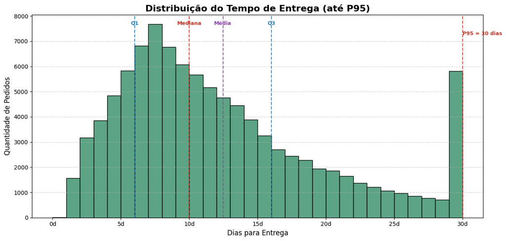

```python
# 1) Garantir datetime nas colunas de orders
orders['order_purchase_timestamp']       = pd.to_datetime(orders['order_purchase_timestamp'], errors='coerce')
orders['order_delivered_customer_date']  = pd.to_datetime(orders['order_delivered_customer_date'], errors='coerce')

# 2) Calcular tempo de entrega (dias) a partir de orders
tempo_entrega = (orders['order_delivered_customer_date'] - orders['order_purchase_timestamp']).dt.days

# 3) Limpar: remover nulos e negativos
tempo = tempo_entrega.dropna()
tempo = tempo[tempo >= 0]

# 4) Estatísticas e P95
p95 = tempo.quantile(0.95)
q1  = tempo.quantile(0.25)
med = tempo.median()
q3  = tempo.quantile(0.75)
media = tempo.mean()

# 5) Clipping para visualizar melhor (até P95)
tempo_clip = tempo.clip(upper=p95)

# 6) Histograma (bins de 1 dia)
bin_width = 1
bins = np.arange(0, tempo_clip.max() + bin_width, bin_width)

plt.figure(figsize=(12,6))
ax = sns.histplot(tempo_clip, bins=bins, kde=False, color="#25865B", edgecolor='black')

plt.title('Distribuição do Tempo de Entrega (até P95)', fontsize=16, fontweight='bold')
plt.xlabel('Dias para Entrega', fontsize=12)
plt.ylabel('Quantidade de Pedidos', fontsize=12)
plt.grid(axis='y', linestyle='--', alpha=0.6)
plt.tight_layout()

# Linhas de estatísticas (usando a distribuição completa, não clipada)
for x, lbl, col in [(q1, 'Q1', '#2980B9'),
                    (med,'Mediana', '#C0392B'),
                    (q3, 'Q3', '#2980B9'),
                    (media, 'Média', '#8E44AD')]:
    plt.axvline(x, color=col, linestyle='--', alpha=0.85)
    plt.text(x, ax.get_ylim()[1]*0.95, lbl, ha='center', color=col, fontsize=9, fontweight='bold')

# Limite P95
plt.axvline(p95, color='#E74C3C', linestyle='--', alpha=0.9)
plt.text(p95, ax.get_ylim()[1]*0.9, f'P95 = {p95:.0f} dias', color='#C0392B', ha='left', fontsize=9, fontweight='bold')

# Formatar eixo X como "Xd"
plt.gca().xaxis.set_major_formatter(mtick.FuncFormatter(lambda x, _: f'{int(x)}d'))

plt.show()
```

```python
# 1) Construir o faturamento por estado a partir do seu df consolidado
# (ajuste a origem se preferir: df_final ou outro DF onde há customer_state/payment_value)
vendas_estado = (
    df_final.groupby('customer_state', as_index=True)['payment_value']
    .sum()
    .to_frame(name='faturamento')
)


estados = read_state(year=2020)  # columns: abbrev_state, name_state, geometry

# 3) Merge pela sigla do estado
gdf = estados.merge(
    vendas_estado,
    left_on='abbrev_state',   # SP, RJ, MG, ...
    right_index=True,         # índice do DataFrame vendas_estado
    how='left'
)

# 4) Pós-processamento
gdf['faturamento'] = gdf['faturamento'].fillna(0.0)
gdf['faturamento_mm'] = gdf['faturamento'] / 1_000_000
```

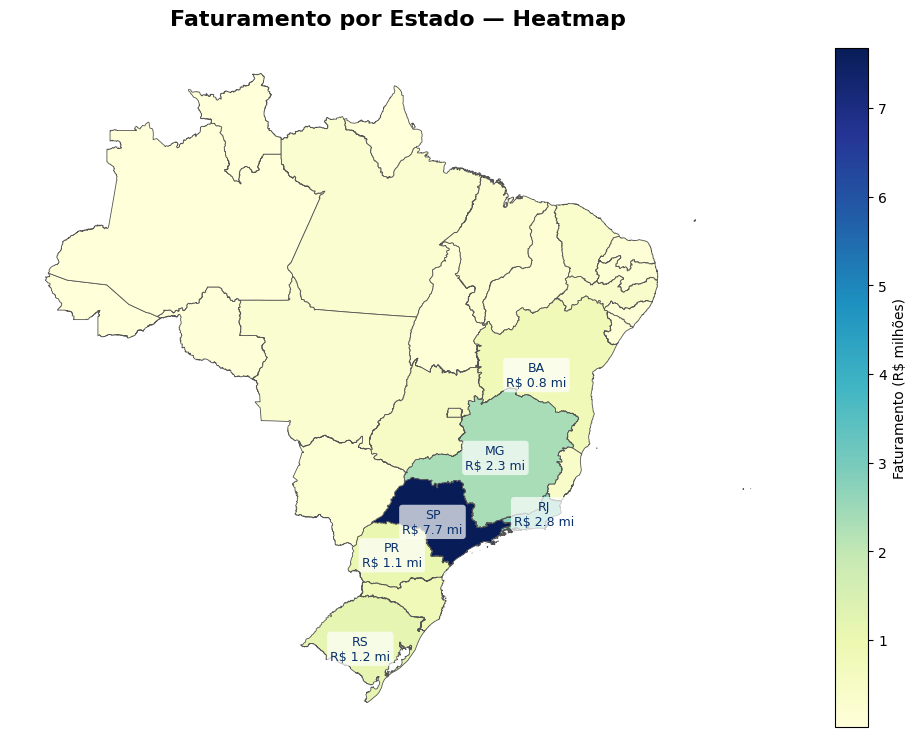

```python
plt.figure(figsize=(10,10))
ax = plt.gca()

# mapa base
gdf.plot(
    column='faturamento_mm',
    cmap='YlGnBu',
    linewidth=0.6,
    edgecolor='#555',
    legend=True,
    legend_kwds={
        'label': "Faturamento (R$ milhões)",  # para colorbar contínuo
        'shrink': 0.7
    },
    ax=ax
)


# título e estética
ax.set_title('Faturamento por Estado — Heatmap', fontsize=16, fontweight='bold', pad=12)
ax.axis('off')

# anotar Top 5 estados
top6 = gdf.nlargest(6, 'faturamento')
for _, row in top6.iterrows():
    x, y = row.geometry.representative_point().coords[0]  # ponto seguro dentro do polígono
    ax.text(x, y, f"{row['abbrev_state']}\nR$ {row['faturamento_mm']:.1f} mi",
            ha='center', va='center', fontsize=9, color='#08306B',
            bbox=dict(boxstyle='round,pad=0.25', fc='white', ec='none', alpha=0.7))

plt.tight_layout()
plt.show()
```

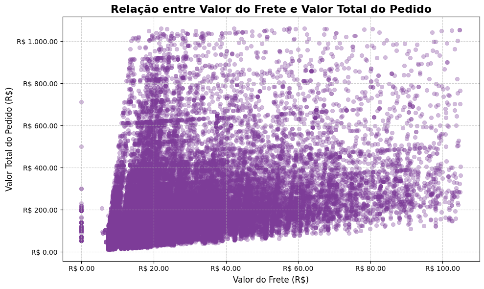

```python
# 1) Agrega por pedido nas tabelas originais
frete_por_pedido = (
    order_items.groupby('order_id', as_index=True)['freight_value']
    .sum()
    .to_frame()
)

faturamento_por_pedido = (
    order_payments.groupby('order_id', as_index=True)['payment_value']
    .sum()
    .to_frame()
)

# 2) Junta no nível do pedido
scatter_df = (
    frete_por_pedido
    .join(faturamento_por_pedido, how='inner')
    .replace([np.inf, -np.inf], np.nan)
    .dropna()
)

# 3) Limpa casos estranhos
scatter_df = scatter_df.query('payment_value > 0 and freight_value >= 0')

# 4) (opcional) recorte de cauda para visualização melhor
x99 = scatter_df['freight_value'].quantile(0.99)
y99 = scatter_df['payment_value'].quantile(0.99)
plot_df = scatter_df[(scatter_df['freight_value'] <= x99) & (scatter_df['payment_value'] <= y99)]

# 5) Scatter + linha de tendência
plt.figure(figsize=(10,6))
ax = sns.scatterplot(
    data=plot_df,
    x='freight_value', y='payment_value',
    alpha=0.35, color='#7D3C98', edgecolor=None
)


# 6) Título, eixos e formatação
plt.title('Relação entre Valor do Frete e Valor Total do Pedido', fontsize=16, fontweight='bold')
plt.xlabel('Valor do Frete (R$)', fontsize=12)
plt.ylabel('Valor Total do Pedido (R$)', fontsize=12)
plt.grid(True, linestyle='--', alpha=0.6)

fmt_rs = mtick.FuncFormatter(lambda v, _: 'R$ ' + f'{v:,.2f}'.replace(',', '.'))
ax.xaxis.set_major_formatter(fmt_rs)
ax.yaxis.set_major_formatter(fmt_rs)

plt.tight_layout()
plt.show()
```

## Avaliação e Conclusões

📈 Avaliação e Conclusões

A análise conduzida ao longo deste notebook permitiu compreender de forma abrangente o comportamento comercial do e-commerce brasileiro, utilizando o método **CRISP-DM** como estrutura de referência. As etapas de **entendimento, preparação, exploração e avaliação** mostraram-se essenciais para transformar dados brutos em **informações estratégicas**.

### 🔍 Principais Insights Obtidos

- O volume de pedidos apresentou **crescimento sazonal**, com variações perceptíveis ao longo dos meses — possivelmente associadas a períodos promocionais e datas comemorativas.
- O **faturamento** concentrou-se nos estados economicamente mais ativos, como **São Paulo, Rio de Janeiro e Minas Gerais**, reforçando a representatividade dessas regiões na operação.
- A **distribuição dos meios de pagamento** evidenciou a predominância do cartão de crédito, refletindo o padrão de consumo digital no Brasil.
- A análise de **tempo de entrega (P95)** revelou uma boa eficiência logística, embora haja espaço para redução nas caudas superiores (entregas fora do padrão).
- O **ticket médio** apresentou variação regional, sugerindo que campanhas personalizadas por estado podem aumentar o desempenho comercial.

### 🚧 Limitações Identificadas

- A ausência de alguns dados (como produtos sem categoria, medidas físicas incompletas e meses sem compras) reduziu a precisão de certas análises.
- Não há informações financeiras detalhadas sobre custos, o que impede o cálculo direto de **margem de lucro ou rentabilidade**.
- O conjunto de dados não abrange variáveis externas (ex.: marketing, sazonalidade macroeconômica), o que limitaria análises preditivas completas.

### 💡 Próximos Passos Recomendados

1. **Aprofundar a análise temporal**, explorando tendências anuais e sazonalidade por categoria de produto.
2. **Integrar novas fontes de dados**, como despesas logísticas ou campanhas de marketing, para análises de rentabilidade.
3. **Desenvolver dashboards interativos** (Power BI ou Streamlit) para acompanhamento contínuo dos indicadores.

> Em suma, o projeto atingiu seu objetivo de **transformar dados operacionais em conhecimento estratégico**, fornecendo uma visão clara do desempenho do e-commerce e das oportunidades de melhoria nos processos comerciais e logísticos.